# **基于深度神经网络的情感分类**

# 一、 实验目的

1. 掌握基于循环神经网络和 TextCNN 的调用
2. 熟悉英文情感分类过程。

# 二、 实验内容

基于循环神经网络和 TextCNN 对英文影评 IMDB 数据集进行分类。 可以直接从 keras 导入预处理好的数据。

# 三、 实验步骤

# 四、模型设置

## 1.循环神经网络

2) 双层 GRU:双层 GRU(每层节点个数 128，激活 tanh)，全连接（1 个节点,激活 sigmoid）。

3) 把 GRU 改成 LSTM。

## 2. TextCNN

2）自己尝试改变以上模型设置。

```python
import keras
(X_train, y_test), (X_valid, y_test) = keras.datasets.imdb.load_data()
X_train[0][:10]
word_index = keras.datasets.imdb.get_word_index()
id_to_word = {id_ + 3: word for word, id_ in word_index.items()}
for id_, token in enumerate(("<pad>", "<sos>", "unk")):
    id_to_word[id_] = token
" ".join([id_to_word[id_] for id_ in X_train[0][:10]])
```

```
'<sos> this film was just brilliant casting location scenery story'
```

```python
import tensorflow_datasets as tfds
datasets, info = tfds.load("imdb_reviews",as_supervised=True, with_info=True)
datasets.keys()
train_size = info.splits["train"].num_examples
test_size = info.splits["test"].num_examples
train_size, test_size
```

```
(25000, 25000)
```

```python
for X_batch, y_batch in datasets["train"].batch(2). take(1):
    for review, label in zip(X_batch.numpy(), y_batch.numpy()) :
        print("Review:", review.decode("utf-8")[:200], "...")
        print("Label:", label, "= Positive" if label else "= Negative")
        print()
```

```
Review: This was an absolutely terrible movie. Don't be lured in by Christopher Walken or Michael Ironside. Both are great actors, but this must simply be their worst role in history. Even their great acting  ...
Label: 0 = Negative

Review: I have been known to fall asleep during films, but this is usually due to a combination of things including, really tired, being warm and comfortable on the sette and having just eaten a lot. However  ...
Label: 0 = Negative
```

```python
def preprocess(X_batch,y_batch):
    X_batch = tf.strings.substr (X_batch,0,300)
    X_batch = tf.strings.regex_replace(X_batch,rb"<br\s*/?>", b" ")
    X_batch = tf.strings.regex_replace(X_batch, b"[^a-zA-Z' ]", b" ")
    X_batch = tf.strings.split(X_batch)
    return X_batch.to_tensor (default_value=b"<pad>"),y_batch
```

```python
from collections import Counter
import tensorflow as tf

vocabulary = Counter()
for X_batch, y_batch in datasets["train"].batch(32).map(preprocess):
    for review in X_batch:
        vocabulary.update(list(review.numpy()))
```

```python
vocabulary.most_common()[:3]
print(len(vocabulary))
vocab_size = 10000
truncated_vocabulary =[word for word, count in vocabulary.most_common()[:vocab_size]]
```

```
53893
```

```python
word_to_id = {word: index for index, word in enumerate(truncated_vocabulary)}
for word in b"This movie was faaaaaantastic".split():
    print(word_to_id.get(word)or vocab_size)
```

```
22
12
11
10000
```

```python
words = tf.constant(truncated_vocabulary)
word_ids = tf.range(len(truncated_vocabulary), dtype=tf.int64)
vocab_init = tf.lookup.KeyValueTensorInitializer(words, word_ids)
num_oov_buckets = 1000
table = tf.lookup. StaticVocabularyTable(vocab_init, num_oov_buckets)
table.lookup (tf.constant([b"This movie was faaaaaantastic".split()]))
```

```
<tf.Tensor: shape=(1, 4), dtype=int64, numpy=array([[   22,    12,    11, 10053]], dtype=int64)>
```

```python
def encode_words(X_batch, y_batch):
    return table.lookup(X_batch), y_batch
train_set = datasets["train"].batch(32).map(preprocess)
train_set = train_set.map(encode_words).prefetch(1)
for X_batch, y_batch in train_set.take(1):
    print(X_batch)
    print(y_batch)

test_set = datasets["test"].batch(32).map(preprocess)
test_set = test_set.map(encode_words).prefetch(1)
```

```
tf.Tensor(
[[  22   11   28 ...    0    0    0]
 [   6   21   70 ...    0    0    0]
 [4099 6881    1 ...    0    0    0]
 ...
 [  22   12  118 ...  331 1047    0]
 [1757 4101  451 ...    0    0    0]
 [3365 4392    6 ...    0    0    0]], shape=(32, 60), dtype=int64)
tf.Tensor([0 0 0 1 1 1 0 0 0 0 0 1 1 0 1 0 1 1 1 0 1 1 1 1 1 0 0 0 1 0 0 0], shape=(32,), dtype=int64)
```

```python
embed_size = 128
model = keras.models.Sequential([
    keras.layers.Embedding(vocab_size + num_oov_buckets, embed_size,
                           mask_zero=True,#忽略padding
                           input_shape=[None]),
    keras.layers.GRU(128, return_sequences=True),
    keras.layers.GRU(128),
    keras.layers.Dense(1, activation="sigmoid")
])
model.compile(loss="binary_crossentropy", optimizer="adam", metrics=["accuracy"])
model.summary()
```

```
Model: "sequential_15"
_________________________________________________________________
 Layer (type)                Output Shape              Param #
=================================================================
 embedding_15 (Embedding)    (None, None, 128)         1408000

 gru_28 (GRU)                (None, None, 128)         99072

 gru_29 (GRU)                (None, 128)               99072

 dense_16 (Dense)            (None, 1)                 129

=================================================================
Total params: 1606273 (6.13 MB)
Trainable params: 1606273 (6.13 MB)
Non-trainable params: 0 (0.00 Byte)
_________________________________________________________________
```

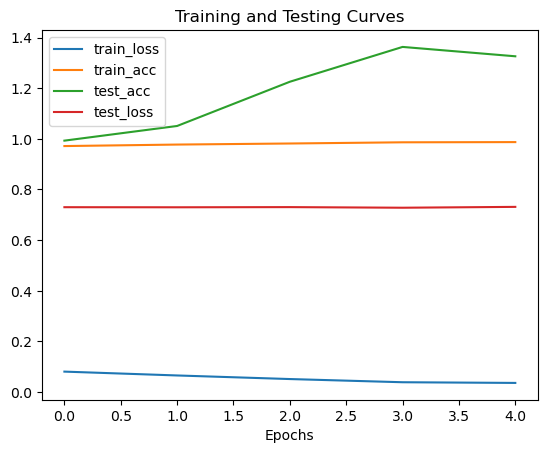

```python
# 训练模型并记录训练历史
history = model.fit(train_set, epochs=5, validation_data=test_set)

plt.plot(history.history['loss'])
plt.plot(history.history['accuracy'])
plt.plot(history.history['val_loss'])
plt.plot(history.history['val_accuracy'])
plt.title('Training and Testing Curves')
plt.xlabel('Epochs')
plt.legend(['train_loss', 'train_acc', 'test_acc', 'test_loss'])
plt.show()
```

```
Model: "sequential_17"
_________________________________________________________________
 Layer (type)                Output Shape              Param #
=================================================================
 embedding_17 (Embedding)    (None, None, 64)          704000

 gru_32 (GRU)                (None, None, 64)          24960

 gru_33 (GRU)                (None, 64)                24960

 dense_18 (Dense)            (None, 1)                 65

=================================================================
Total params: 753985 (2.88 MB)
Trainable params: 753985 (2.88 MB)
Non-trainable params: 0 (0.00 Byte)
_________________________________________________________________
```

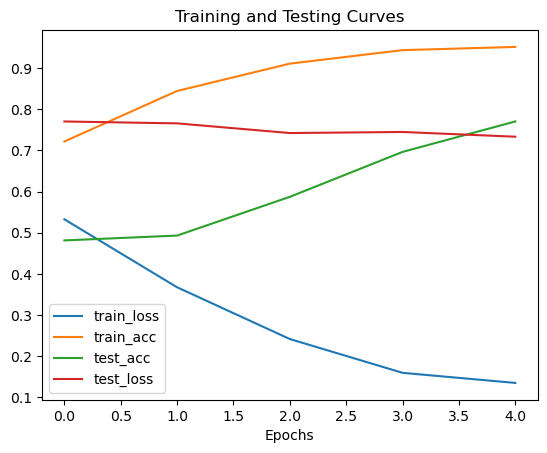

```python
embed_size = 64
model = keras.models.Sequential([
    keras.layers.Embedding(vocab_size + num_oov_buckets, embed_size,
                           mask_zero=True,#忽略padding
                           input_shape=[None]),
    keras.layers.GRU(64, return_sequences=True),
    keras.layers.GRU(64),
    keras.layers.Dense(1, activation="sigmoid")
])
model.compile(loss="binary_crossentropy", optimizer="adam", metrics=["accuracy"])
model.summary()
# 训练模型并记录训练历史
history = model.fit(train_set, epochs=5, validation_data=test_set)

plt.plot(history.history['loss'])
plt.plot(history.history['accuracy'])
plt.plot(history.history['val_loss'])
plt.plot(history.history['val_accuracy'])
plt.title('Training and Testing Curves')
plt.xlabel('Epochs')
plt.legend(['train_loss', 'train_acc', 'test_acc', 'test_loss'])
plt.show()
```

```
Model: "sequential_18"
_________________________________________________________________
 Layer (type)                Output Shape              Param #
=================================================================
 embedding_18 (Embedding)    (None, None, 128)         1408000

 gru_34 (GRU)                (None, None, 128)         99072

 gru_35 (GRU)                (None, None, 128)         99072

 gru_36 (GRU)                (None, 128)               99072

 dense_19 (Dense)            (None, 1)                 129

=================================================================
Total params: 1705345 (6.51 MB)
Trainable params: 1705345 (6.51 MB)
Non-trainable params: 0 (0.00 Byte)
_________________________________________________________________
```

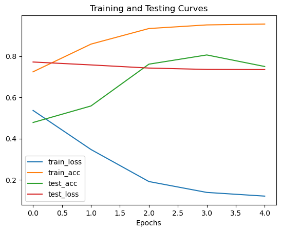

```python
embed_size = 128
model = keras.models.Sequential([
    keras.layers.Embedding(vocab_size + num_oov_buckets, embed_size,
                           mask_zero=True,#忽略padding
                           input_shape=[None]),
    keras.layers.GRU(128, return_sequences=True),
    keras.layers.GRU(128, return_sequences=True),
    keras.layers.GRU(128),
    keras.layers.Dense(1, activation="sigmoid")
])
model.compile(loss="binary_crossentropy", optimizer="adam", metrics=["accuracy"])
model.summary()
history = model.fit(train_set, epochs=5, validation_data=test_set)

plt.plot(history.history['loss'])
plt.plot(history.history['accuracy'])
plt.plot(history.history['val_loss'])
plt.plot(history.history['val_accuracy'])
plt.title('Training and Testing Curves')
plt.xlabel('Epochs')
plt.legend(['train_loss', 'train_acc', 'test_acc', 'test_loss'])
plt.show()
```

```
Model: "sequential_19"
_________________________________________________________________
 Layer (type)                Output Shape              Param #
=================================================================
 embedding_19 (Embedding)    (None, None, 128)         1408000

 gru_37 (GRU)                (None, None, 128)         99072

 gru_38 (GRU)                (None, None, 128)         99072

 gru_39 (GRU)                (None, 128)               99072

 dense_20 (Dense)            (None, 1)                 129

=================================================================
Total params: 1705345 (6.51 MB)
Trainable params: 1705345 (6.51 MB)
Non-trainable params: 0 (0.00 Byte)
_________________________________________________________________
```

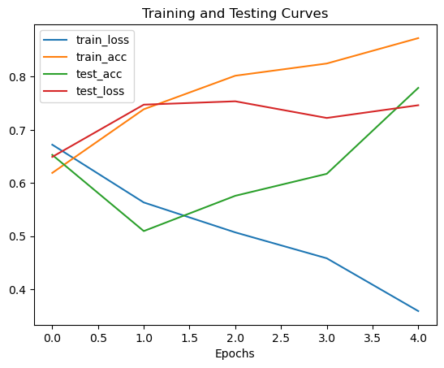

```python
embed_size = 128
model = keras.models.Sequential([
    keras.layers.Embedding(vocab_size + num_oov_buckets, embed_size,
                           mask_zero=True,#忽略padding
                           input_shape=[None]),
    keras.layers.GRU(128, return_sequences=True),
    keras.layers.GRU(128, return_sequences=True),
    keras.layers.GRU(128),
    keras.layers.Dense(1, activation="tanh")
])
model.compile(loss="binary_crossentropy", optimizer="adam", metrics=["accuracy"])
model.summary()
history = model.fit(train_set, epochs=5, validation_data=test_set)

plt.plot(history.history['loss'])
plt.plot(history.history['accuracy'])
plt.plot(history.history['val_loss'])
plt.plot(history.history['val_accuracy'])
plt.title('Training and Testing Curves')
plt.xlabel('Epochs')
plt.legend(['train_loss', 'train_acc', 'test_acc', 'test_loss'])
plt.show()
```

- LSTM

```
Model: "sequential_20"
_________________________________________________________________
 Layer (type)                Output Shape              Param #
=================================================================
 embedding_20 (Embedding)    (None, None, 128)         1408000

 lstm_2 (LSTM)               (None, None, 128)         131584

 lstm_3 (LSTM)               (None, 128)               131584

 dense_21 (Dense)            (None, 1)                 129

=================================================================
Total params: 1671297 (6.38 MB)
Trainable params: 1671297 (6.38 MB)
Non-trainable params: 0 (0.00 Byte)
_________________________________________________________________
```

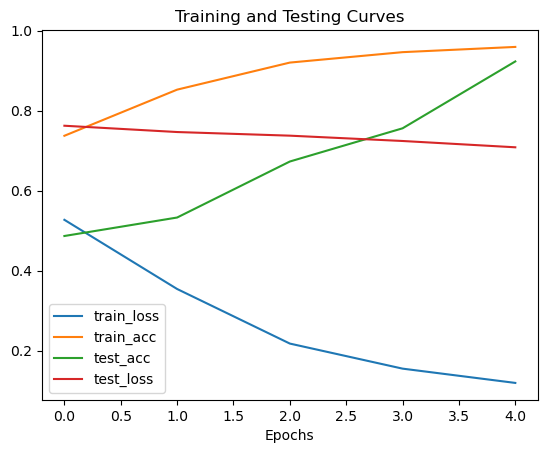

```python
embed_size = 128
model = keras.models.Sequential([
    keras.layers.Embedding(vocab_size + num_oov_buckets, embed_size,
                           mask_zero=True, input_shape=[None]),
    keras.layers.LSTM(128, return_sequences=True),  # 将GRU改为LSTM
    keras.layers.LSTM(128),  # 将GRU改为LSTM
    keras.layers.Dense(1, activation="sigmoid")
])
model.compile(loss="binary_crossentropy", optimizer="adam", metrics=["accuracy"])
model.summary()
history = model.fit(train_set, epochs=5, validation_data=test_set)

plt.plot(history.history['loss'])
plt.plot(history.history['accuracy'])
plt.plot(history.history['val_loss'])
plt.plot(history.history['val_accuracy'])
plt.title('Training and Testing Curves')
plt.xlabel('Epochs')
plt.legend(['train_loss', 'train_acc', 'test_acc', 'test_loss'])
plt.show()
```

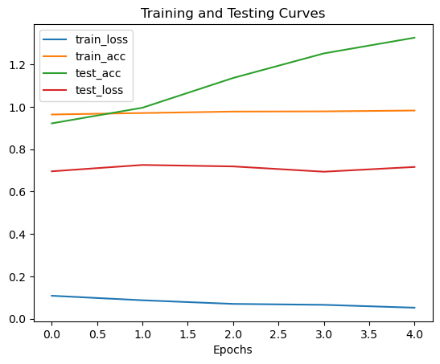

```python
from keras.layers import Conv1D, GlobalMaxPooling1D

embed_dim = 200
filters = 64
kernel_size = [2, 3, 4]

model4 = keras.Sequential([
    keras.layers.Embedding(vocab_size + num_oov_buckets, embed_dim, input_shape=[None]),
    keras.layers.Conv1D(filters=filters, kernel_size=kernel_size[0], activation='relu'),
    keras.layers.Conv1D(filters=filters, kernel_size=kernel_size[1], activation='relu'),
    keras.layers.Conv1D(filters=filters, kernel_size=kernel_size[2], activation='relu'),
    keras.layers.GlobalMaxPooling1D(),
    keras.layers.Dense(64, activation='relu'),
    keras.layers.Dense(1, activation='sigmoid')
])

# 编译模型
model.compile(loss='binary_crossentropy', optimizer='adam', metrics=['accuracy'])
history = model.fit(train_set, epochs=5, validation_data=test_set)

# 训练模型
plt.plot(history.history['loss'])
plt.plot(history.history['accuracy'])
plt.plot(history.history['val_loss'])
plt.plot(history.history['val_accuracy'])
plt.title('Training and Testing Curves')
plt.xlabel('Epochs')
plt.legend(['train_loss', 'train_acc', 'test_acc', 'test_loss'])
plt.show()
```

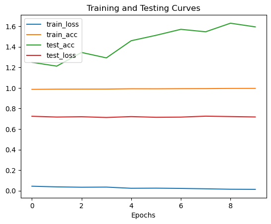

```python
from keras.layers import Conv1D, GlobalMaxPooling1D

embed_dim = 200
filters = 64
kernel_size = [2, 3, 4]

model4 = keras.Sequential([
    keras.layers.Embedding(vocab_size + num_oov_buckets, embed_dim, input_shape=[None]),
    keras.layers.Conv1D(filters=filters, kernel_size=kernel_size[0], activation='relu'),
    keras.layers.Conv1D(filters=filters, kernel_size=kernel_size[1], activation='relu'),
    keras.layers.Conv1D(filters=filters, kernel_size=kernel_size[2], activation='relu'),
    keras.layers.GlobalMaxPooling1D(),
    keras.layers.Dense(64, activation='relu'),
    keras.layers.Dense(1, activation='sigmoid')
])

# 编译模型
model.compile(loss='binary_crossentropy', optimizer='adam', metrics=['accuracy'])
history = model.fit(train_set, epochs=10, validation_data=test_set)

# 训练模型
plt.plot(history.history['loss'])
plt.plot(history.history['accuracy'])
plt.plot(history.history['val_loss'])
plt.plot(history.history['val_accuracy'])
plt.title('Training and Testing Curves')
plt.xlabel('Epochs')
plt.legend(['train_loss', 'train_acc', 'test_acc', 'test_loss'])
plt.show()
```